### Cargar bibliotecas

Acá cargo las librerías necesarias…

```r
library(sf)
library(ggplot2)
library(tidyverse)
library(gridExtra)
library(tinytex)
library(ctmm)
library(showtext)
```

### Localizaciones

Esta tabla tiene las localizaciones de todos los grupos de monos caí, incluyendo los del PNI y Arauco.

```r
hr <- read_rds('hr.RDS')

head(hr)
```

| individual.local.identifier | location.lat | location.long | timestamp | year | grupo | area | estacion2 | descortezado | month | bimonth |
| --- | --- | --- | --- | --- | --- | --- | --- | --- | --- | --- |
| col.oto | -25.813371 | -54.507176 | 2022-03-18 09:30:00 | 2022 | Columba | Arauco | verano | no | mar | mar-abr |
| col.oto | -25.8090878 | -54.5091997 | 2022-03-18 10:00:00 | 2022 | Columba | Arauco | verano | no | mar | mar-abr |
| col.oto | -25.8099306 | -54.5091277 | 2022-03-18 10:30:00 | 2022 | Columba | Arauco | verano | no | mar | mar-abr |
| col.oto | -25.8098658 | -54.5075434 | 2022-03-18 11:00:00 | 2022 | Columba | Arauco | verano | no | mar | mar-abr |
| col.oto | -25.8116161 | -54.5084076 | 2022-03-18 12:00:00 | 2022 | Columba | Arauco | verano | no | mar | mar-abr |
| col.oto | -25.812394 | -54.5053111 | 2022-03-18 12:30:00 | 2022 | Columba | Arauco | verano | no | mar | mar-abr |

Brevementemente (todo el detalle está en otro script, bastante más largo), la data.frame tiene 21103 localizaciones

```r
hr %>%
  group_by(area) %>%
  summarise(locs = n())
```

| area | locs |
| --- | --- |
| Arauco | 9755 |
| PN Iguazu | 11348 |

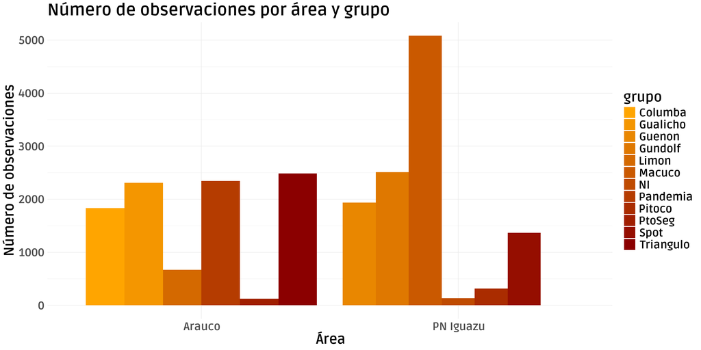

```r
# me gusta esta fuente je

font_add_google("Ruda", "ruda")
showtext_auto()

hr_summ<-hr %>%
  group_by(area, grupo) %>%
  summarise(locs = n())

color_palette <- colorRampPalette(c("orange", "darkred"))(length(unique(hr_summ$grupo)))

ggplot(hr_summ, aes(x = area, y = locs, fill = grupo)) +
  geom_bar(stat = "identity", position = "dodge") +
  labs(title = "Número de observaciones por área y grupo",
       x = "Área", y = "Número de observaciones") +
  scale_fill_manual(values = color_palette) +
  theme_minimal()+
  theme(text = element_text(
      family = "ruda",
      face='bold',
      size =40))
```

#### Chequeo si se trata de animales residentes

Detalles en otro Script. Hice variogramas NI fue descartado por falta de datos. Acá pongo los dos con menos datos desp de ‘NI’: PtoSeg y Pitoco; ambos muestran comportamiento residente. Un *variograma* describe la dependencia espacial o temporal entre observaciones secuenciales. Básicamente ayuda a detectar patrones en datos espaciales para saber si el animal es residente o errante (o dispersante, floater, migrante… como se llame). El variograma evalúa cómo cambia la semi-varianza entre dos puntos en función de la distancia (o tiempo) que los separa.

$$\gamma(h) = \frac{1}{2N(h)} \sum_{i=1}^{N(h)} (Z(x_i) - Z(x_i + h))^2$$

- $\gamma(h)$ es la semi-varianza a un intervalo $h$ (lag).
- $N(h)$ es el número de pares de puntos separados por la distancia $h$.
- $Z(x_i)$ es el valor observado en la posición $x_i$.
- $Z(x_i + h)$ es el valor observado en la posición $x_i + h$.

A medida que $h$ aumenta, la semi-varianza tiende a estabilizarse en un valor llamado *sill* (asíntota), lo que indica que las observaciones a distancias más grandes ya no están correlacionadas entre sí. El punto donde el variograma alcanza la meseta se llama range (alcance) y nos indica el rango espacial dentro del cual las observaciones están correlacionadas.Si el variograma muestra una meseta claramente definida, esto sugiere que el bicho tiende a permanecer dentro de un área fija, es decir, tiene un comportamiento residente.

```r
library('ctmm')
Pseg <- hr %>%
  filter(grupo == 'PtoSeg')

Pseg_t <- as.telemetry(Pseg,
                      tz = "America/Argentina/Buenos_Aires")

dt <- c(1) %#% "hour"

vg.Pseg <- variogram(Pseg_t,
                    dt = dt)

Pseg_guess <- ctmm.guess(Pseg_t,
                            CTMM = ctmm(error = 12.5),
                            interactive = FALSE)

Pitoco <- hr %>%
  filter(grupo == 'Pitoco')

Pitoco_t <- as.telemetry(Pitoco,
                      tz = "America/Argentina/Buenos_Aires")

dt <- c(1) %#% "hour"

vg.pitoco <- variogram(Pitoco_t,
                    dt = dt)

Pitoco_guess <- ctmm.guess(Pitoco_t,
                            CTMM = ctmm(error = 12.5),
                            interactive = FALSE)
```

Son feos los gráficos pero son residentes, así que podes estimar AKDEs

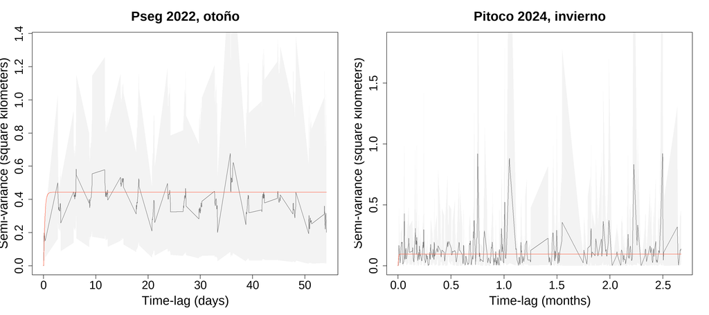

```r
par(mfrow = c(1, 2))

plot(vg.Pseg,
     Pseg_guess,
     fraction = 0.75,
     col.CTMM = "tomato",
     lwd.model = 2,
     cex=5,
     main= 'Pseg 2022, otoño',
     col = rgb(0, 0, 0, alpha = 0.5),
     cex.main = 4,
     cex.lab = 3.8,
     cex.axis =3.5)
plot(vg.pitoco,
     Pitoco_guess,
     fraction = 0.75,
     col.CTMM = "tomato",
     lwd.model = 2,
     main= 'Pitoco 2024, invierno',
     col = rgb(0, 0, 0, alpha = 0.5),
     cex.main = 4,
     cex.lab = 3.8,
     cex.axis =3.5)
```

#### Cargo las AKDE 95% y AKDE 50%

Los datos de la siguiente table fueron obtenidos después de correr una función que hice _‘*sim_akde.R*’, para ver más detalles de la [función](https://github.com/ValentinZarate/capuchins_hrs/blob/main/sim_akde.md). Esta función genera una tabla de resumen de las AKDE 95 y 50 para cada set de datos independiente; en este caso es localizaciones mensuales para cada grupo (AKDEs de meses distintos).

Además, *sim_akde.R* genera un **shape file** por cada AKDE, esto lo vamos a usar despúes.

```r
hr_month <- read_csv('ctmm_fits/monthly/akde_cvs/hr_mont_all.csv')

hr_month <- hr_month %>%
  mutate(across(c(area,
                  best_fit),
                as.factor))

head(hr_month)
```

| hr_id | individual.local.identifier | area | best_fit | akde_95_area | akde_50_area | n_locs | n_ind |
| --- | --- | --- | --- | --- | --- | --- | --- |
| 1 | Columba_2022_mar | arauco | OUF error | 421.0779 | 77.29626 | 252 | 19 |
| 2 | Columba_2022_abr | arauco | OUF anisotropic error | 368.2268 | 52.77831 | 663 | 19 |
| 3 | Columba_2022_may | arauco | OUF anisotropic error | 484.5713 | 46.75162 | 375 | 19 |
| 4 | Columba_2022_ago | arauco | OUf error | 438.4733 | 99.80976 | 85 | 19 |
| 5 | Columba_2022_sep | arauco | OUf error | 501.8334 | 137.08109 | 96 | 19 |
| 6 | Columba_2022_oct | arauco | OUf error | 389.2566 | 84.55560 | 41 | 19 |

Separo los nombres para tener grupos, años y meses por separado. Este *individual.local.identifier* coincide con el nombre del **shapefile**, es importante mantener esto en algún lado (el RDS queda como está).

```r
hr_month <- hr_month %>%
  separate(individual.local.identifier,
           into = c("grupo", "year", "mes"),
           sep = "_") %>%
  mutate(ratio = akde_95_area/akde_50_area)

head(hr_month)
```

| hr_id | grupo | year | mes | area | best_fit | akde_95_area | akde_50_area | n_locs | n_ind | ratio |
| --- | --- | --- | --- | --- | --- | --- | --- | --- | --- | --- |
| 1 | Columba | 2022 | mar | arauco | OUF error | 421.0779 | 77.29626 | 252 | 19 | 5.447584 |
| 2 | Columba | 2022 | abr | arauco | OUF anisotropic error | 368.2268 | 52.77831 | 663 | 19 | 6.976858 |
| 3 | Columba | 2022 | may | arauco | OUF anisotropic error | 484.5713 | 46.75162 | 375 | 19 | 10.364802 |
| 4 | Columba | 2022 | ago | arauco | OUf error | 438.4733 | 99.80976 | 85 | 19 | 4.393090 |
| 5 | Columba | 2022 | sep | arauco | OUf error | 501.8334 | 137.08109 | 96 | 19 | 3.660851 |
| 6 | Columba | 2022 | oct | arauco | OUf error | 389.2566 | 84.55560 | 41 | 19 | 4.603558 |

Agrego una columan de productividad, considerando Junio, Julio, Agosto y Septiembre como baja y el resto como alta. Es medio medio esto, pero después se puede afinar mejor, inclusive quizás agregar una variable continua (scores) en base a fenología y estructura de bosque.

```r
hr_month <- hr_month %>%
  mutate(productividad = if_else(
    mes %in% c(
      'jun',
      'jul',
      'ago',
      'sep'),
    'Baja',
    'Alta'))
```

#### Agrego grosor de floema y Fuerza de descortezado

Usando datos de grosor de floema y de fuerza de descortezado calculo la profitability y creo está nueva data.frame. No son datos mensuales, sino cada 45 días y a veces más. Así que en los meses vacíos se agregó la media entre el mes anterior y el posterior. También puede mejorarse, por ejemplo con un modelo que ajuste el cambio de estas medidas en el tiempo y prediga para los meses vacíos.

```r
profit <- read_csv ('ctmm_fits/monthly/akde_cvs/fza_gros.csv')

profit <-profit %>% mutate(prof = g_arriba/fza) %>%
  separate(mes,
           into = c("mes", "day"),
           sep = "-")

monthly_profit <- profit %>%
  group_by(mes) %>%
  summarise(media_prof = mean(prof, na.rm = TRUE)) %>%
  separate(mes, into = c("mes", "year"), sep = "-") %>%
  mutate(year = paste0("20", year))

colnames(monthly_profit)
```

```
## [1] "mes"        "year"       "media_prof"
```

Le filtro Arauco a la otra data.frame y le acoplo está nueva columna de profitabilidad, usando mes y año como ‘match’

```r
hr_month_arauco <- hr_month %>%
  filter (area == 'Arauco')

hr_monthly_arauco <- hr_month_arauco %>%
  left_join(monthly_profit, by = c("mes" = "mes", "year" = "year"))
```

## Shapes

La funcion ‘sim_akde’ guardo varios Shapefiles de acuerdo a cada área de acción (AKDE95) y área núcleo (AKDE50). Estos shapes no solo van a servir para hacer mapas sino también para calcular cosas importantes, como por ejemplo la proporcion de Bosque Nativo sin manejo (BNSM) o pinares…

Son muchos shapes (2 por cada área de acción, o sea 190)

```r
archivos_shp <-
  list.files(path = "ctmm_fits/monthly/shapes",
             pattern = "\\.shp$",
             full.names = TRUE)

# Leo todos los Shapes de la carpeta 'monthly' (ahí los guardó sim_akde) basandome en la terminación del archivo. Le dejo los full.names, sim_akde lo guardó conservando grupo_año_mes, justamente para luego poder desmembrarlo en una data.frame y tener los mismos nombres que la tabla resumen de los AKDE.
```

Aplico st_read a todos los elementos de la lista. Acá tuve que sabar todos los pasos porque st_read me daba muchisimos mensajes automaticos que no hubo forma de sacar del ‘html’. Incluía CRS de cada uno de lso 190 shapes, el bbox, bla bla..Básicamente hice esto

- **lista_shapefiles <- lapply(archivos_shp, st_read)**
- **write_rds(lista_shapefiles, ‘lista_shapefiles.rds’)**

```r
lista_shapefiles <- read_rds('lista_shapefiles.rds')
```

Agrego la capa de BNSM de Arauco

```r
BNSM_shapefile <- st_read("ctmm_fits/monthly/shapes/BNSM.shp")
```

Hago la lista vacía para poder ir guardando todo lo que vaya haciendo

```r
resultados <- list()
```

En esta primera linea extraigo el CRS que usaron los de Arauco para hacer su shape (quizás pusieron uno raro)

```r
crs_bsnm <- st_crs(BNSM_shapefile)
```

Lapply itera sobre todos los shape (los 190) y reproyecta las coordenadas segun el CRS de la capa BNSM, esto lo hace con la st_transform. Todo eso queda en lista_shapefiles… que tiene todo en el mismo CRS.

- El bucle ‘for’ recorre cada shapefile en lista_shapefiles_transformada.
- En cada iteración, se queda con el nombre del archivo usando basename(), que devuelve solo el nombre del archivo sin la ruta completa (para identificar qué arcshivo se está procesando).
- Luego, calcula la intersección geométrica entre el shapefile transformado y BNSM_shapefile usando st_intersection(). Esto devuelve la geometría que corresponde al área común (superposición) entre los dos shapefiles.
- Desp, calcula el área total del shapefile transformado con st_area(), que devuelve las áreas de todas las geometrías dentro del shapefile, y desp se suman estas áreas usando sum().
- También calcula el área de la intersección (es decir, la superposición entre el shapefile actual y BNSM_shapefile).
- Caclula la proporcion con la division… y manda todo a un *data.frame*

```r
lista_shapefiles_transformada <- lapply(lista_shapefiles, function(shapefile) {
  st_transform(shapefile, crs_bsnm)
})


for (i in seq_along(lista_shapefiles_transformada)) {

  nombre_shape <- basename(archivos_shp[i])


  interseccion <- st_intersection(lista_shapefiles_transformada[[i]], BNSM_shapefile)


  area_shape <- sum(st_area(lista_shapefiles_transformada[[i]]))
  area_interseccion <- sum(st_area(interseccion))


  proporcion <- as.numeric(area_interseccion / area_shape)


  resultados[[i]] <- data.frame(
    Shape = nombre_shape,
    Proporcion_BNSM = proporcion)
}
```

*do.call* conviernte todos los resultados de la lista en un data.frame

```r
df_resultados <- do.call(rbind, resultados)
```

Como quedo el nombre feo e inmanejable lo separo

```r
df_resultados <- df_resultados %>%
  separate(Shape,
           into = c('grupo', 'year', 'mes', 'akde', 'isopleth'),
           sep = '_')
head(df_resultados)
```

|  | grupo | year | mes | akde | isopleth | Proporcion_BNSM |
| --- | --- | --- | --- | --- | --- | --- |
| 1 | BNSM.shp | NA | NA | NA | NA | 1.0000091 |
| 2 | Columba | 2022 | abr | akde | 50.shp | 0.3618558 |
| 3 | Columba | 2022 | abr | akde | 95.shp | 0.1893295 |
| 4 | Columba | 2022 | ago | akde | 50.shp | 0.3254335 |
| 5 | Columba | 2022 | ago | akde | 95.shp | 0.1579224 |
| 6 | Columba | 2022 | mar | akde | 50.shp | 0.2635595 |

Le saco .shp, no me sirve y va a ser imposible matchearlo con la otra tabla para agregar las proporcioens lo hago ‘ancho’ para poder separar AKDE95 y akde50 en distintas columnas, más similar a la otra df.

```r
df_resultados_wide <- df_resultados %>%
  mutate(isopleth = gsub("\\.shp", "", isopleth)) %>%
  pivot_wider(names_from = isopleth,
              values_from = Proporcion_BNSM,
              names_prefix = "prop_bnsm_")
```

ahora si se puede unir los resultados… por las guardo otra df

```r
hr_month_actualizado <- hr_month %>%
  left_join(df_resultados_wide, by = c("grupo", "year", "mes"))
```

# Plots de los shapes

Ahora quiero ver si esto tiene sentido, intento visualizar un área de acción cualquier para poder ver si están coincidiendo en el espacio y las proporciones fueron calculadas coherentemente (aunque los valores parecen indicar que si)

```r
BNSM_shapefile <- st_transform(BNSM_shapefile, crs = 4326)
lista_shapefiles[[3]] <- st_transform(lista_shapefiles[[3]], crs = 4326)

# me aseguro que coincidan en su sistema de referencia de coordenadas

lista_shapefiles[[3]] <- st_transform(lista_shapefiles[[3]], st_crs(BNSM_shapefile))

# esta bbox me va a servir para hacer zoom sobre el área de accion '3'.

bbox_shape <- st_bbox(lista_shapefiles[[3]])
```

Por ejemplo, con zoom de 0.4 sobre los limites del poligono. Es decir alejo un 40%.

```r
bbox_shape <- st_bbox(lista_shapefiles[[3]])
x_margin <- (bbox_shape["xmax"] - bbox_shape["xmin"]) * 0.4
y_margin <- (bbox_shape["ymax"] - bbox_shape["ymin"]) * 0.4
```

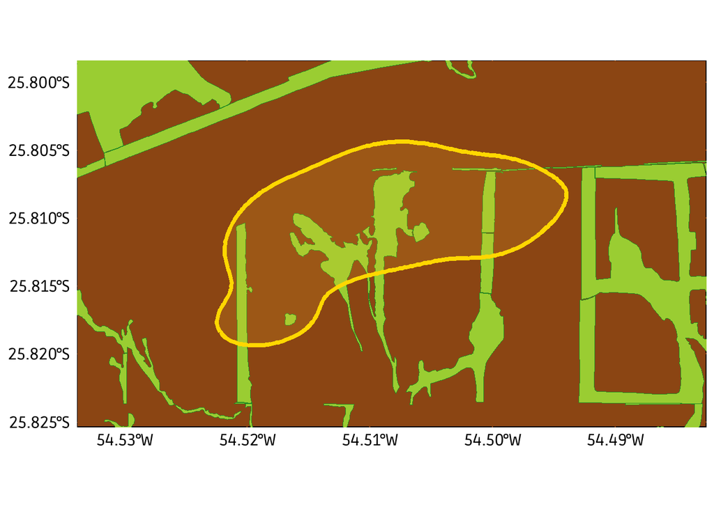

```r
ggplot() +
  geom_sf(
    data = BNSM_shapefile,
    fill = "olivedrab3",
    color = "forestgreen") +
  geom_sf(
    data = lista_shapefiles[[3]],
    fill = adjustcolor("goldenrod1", alpha.f = 0.15),
    color = "gold",
    lwd = 1.5) +
  coord_sf(
    xlim = c(bbox_shape["xmin"] - x_margin, bbox_shape["xmax"] + x_margin),
    ylim = c(bbox_shape["ymin"] - y_margin, bbox_shape["ymax"] + y_margin),
    expand = FALSE) +
  theme_minimal() +
  labs() +
  theme(
    text = element_text(
      family = "ruda",
      face = "bold",
      size = 28),
    axis.text.x = element_text(
      color = "black",
      size = 23,
      face = "bold"),
    axis.text.y = element_text(
      color = "black",
      size = 23,
      face = "bold"),
    panel.background = element_rect(fill = "saddlebrown"),
    plot.background = element_rect(fill = "white", color = NA),
    panel.grid.major = element_line(color = "saddlebrown"),
    panel.grid.minor = element_line(color = "saddlebrown"))
```

Bien, tiene bastante sentido.

Veo bien a quien corresponde, aunque es de Columba no sé año y mes

```r
lista_shapefiles[[3]]$name
```

```
## [1] "Columba_2022_abr 95% est"
```

Veo cuál es el valor de BNSM

```r
ej <- df_resultados %>%
  filter(grupo == "Columba", year == "2022", mes == "abr", isopleth == '95.shp') %>%
  pull(Proporcion_BNSM)

paste("Proporción BNSM:", ej)
```

```
## [1] "Proporción BNSM: 0.189329490911775"
```

Una vez chequeado esto Guardo los archivos para que me vaya quedando una data final

```r
write.csv(hr_month_actualizado, 'hrr_months_all.csv')
```

Sigo con la data.frame final para poder avanzar con gráficos y demás

```r
hr_month <- read.csv('ctmm_fits/monthly/akde_cvs/monthly_all_final.csv')
```

Esta dataframe incluye las proporciones de bnsm para las AKDE50 y AKDE95 así como las áreas totales de BNSM (en el PNI son las mismas).

Para graficar hago una paleta de colores, cambio nombres de los levels y cargo una letra clara

```r
colores <- c('orange3', 'palegreen4')

levels(hr_month$area) <- c('Arauco', 'PNIguazú')

library(showtext)
font_add_google("Ruda", "ruda")
showtext_auto()
```

Primer gráfico

```r
ratio <- ggplot(hr_month, aes(x = area, y = ratio, fill = area)) +
  facet_wrap( ~ productividad) +
  geom_boxplot(outlier.shape = NA) +
  scale_fill_manual(values = colores) +
  geom_jitter(
    aes(size = n_locs),
    alpha = 0.3,
    shape = 20,
    color = 'grey10',
    width = 0.3,
    height = 0.3) +
  coord_cartesian(ylim = c(1, 11)) +
  scale_y_continuous(breaks = seq(1, 11, by = 1)) +
  theme_bw() +
  guides(size = "none",
         alpha = "none",
         color = "none") +
  labs(y = "Ratio AKDE 95/50",
       title = "Productividad de frutos",
       fill = "Área") +
  guides(alpha = "none",
         color = "none") +
  theme(
    text = element_text(
      family = "ruda",
      size = 50,
      face = 'bold'),
    axis.text.x = element_text(
      size = 0,
      angle = 45,
      color = "grey18",
      vjust = 0.6,
      hjust = 0.5),
    axis.title.x = element_text(size = 0),
    axis.title.y = element_text(size = 45,
                                face = "bold",
                                vjust = 1.5))
akde50 <-ggplot(hr_month, aes(x = area, y = akde_50_area, fill = area)) +
  facet_wrap(~ productividad) +
  geom_boxplot(outlier.shape = NA) +
  scale_fill_manual(values = colores) +
  geom_jitter(
    aes(size = n_locs),
    alpha = 0.4 ,
    shape = 20,
    color = 'grey18',
    width = 0.3,
    height = 0.05) +
  coord_cartesian(ylim = c(0, 140)) +
  scale_y_continuous(breaks = seq(0, 200, by = 20))+
  labs(y = "AKDE 50%",
    title = "Productividad de frutos",
    fill = "Área") +
  theme_bw() +
  guides(size='none',
         alpha = "none",
         color = "none") +
  theme(text = element_text(
      family = "ruda",
      size = 50,
      face = 'bold'),
    axis.text.x = element_text(
      size = 0,
      angle = 45,
      color = "grey18",
      vjust = 0.6,
      hjust = 0.5),
    axis.title.x = element_text(size = 0),
    axis.title.y = element_text(
      size = 45,
      face = "bold",
      vjust = 1.5))

akde95 <-ggplot(hr_month, aes(x = area, y = akde_95_area, fill = area)) +
  facet_wrap(~ productividad) +
  geom_boxplot(outlier.shape = NA) +
  scale_fill_manual(values = colores) +
  geom_jitter(aes(size = n_locs),
              alpha = 0.2,
              shape = 20,
              color = 'grey8',
              width = 0.3,
              height = 0.1) +
  coord_cartesian(ylim = c(50, 510)) +
  scale_y_continuous(breaks = seq(50, 510, by = 50)) +
  theme_bw() +
  guides(size = "none", alpha = "none", color = "none") +
  labs(y = "AKDE 95%",
       title = "Productividad de frutos",
       fill = "Área") +
  guides(alpha = "none",
         color = "none") +
  theme(text = element_text(
    family = "ruda",
    size = 50,
    face = 'bold'),
    axis.text.x = element_text(
      size = 0,
      angle = 45,
      color = "grey18",
      vjust = 0.6,
      hjust = 0.5),
    axis.title.x = element_text(size = 0),
    axis.title.y = element_text(
      size = 45,
      face = "bold",
      vjust = 1.5))
```

Los uno en una grilla

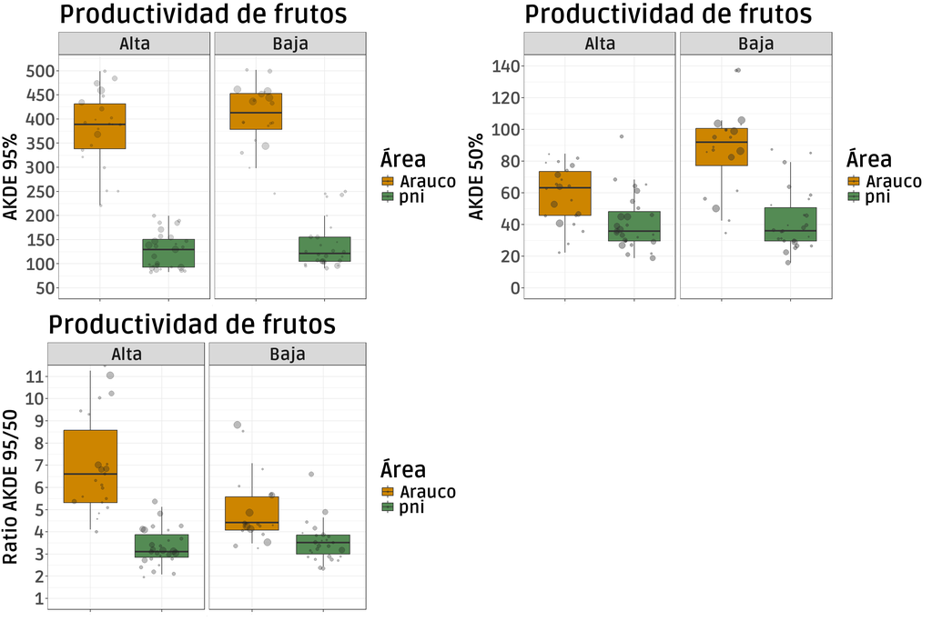

```r
grid.arrange(akde95, akde50, ratio, ncol = 2)
```

**Solo Bosque Nativo** Reestimando usando las proporciones que se calcularon antes

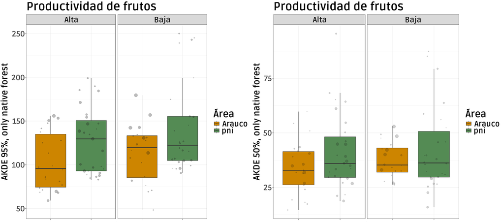

```r
bn_area95 <- ggplot(hr_month, aes(x = area, y = bnsm_area_akde95, fill = area)) +
  facet_wrap( ~ productividad) +
  geom_boxplot(outlier.shape = NA) +
  scale_fill_manual(values = colores) +
  geom_jitter(
    aes(size = n_locs),
    alpha = 0.3,
    shape = 20,
    color = 'grey10',
    width = 0.3,
    height = 0.3) +
  theme_bw() +
  guides(size = "none",
         alpha = "none",
         color = "none") +
  labs(y = "AKDE 95%, only native forest",
       title = "Productividad de frutos",
       fill = "Área") +
  guides(alpha = "none",
         color = "none") +
  theme(
    text = element_text(
      family = "ruda",
      size = 50,
      face = 'bold'),
    axis.text.x = element_text(
      size = 0,
      angle = 45,
      color = "grey18",
      vjust = 0.6,
      hjust = 0.5),
    axis.title.x = element_text(size = 0),
    axis.title.y = element_text(size = 45,
                                face = "bold",
                                vjust = 1.5))


bn_area50 <- ggplot(hr_month, aes(x = area, y = bnsm_area_akde50, fill = area)) +
  facet_wrap(~ productividad) +
  geom_boxplot(outlier.shape = NA) +
  scale_fill_manual(values = colores) +
  geom_jitter(aes(size = n_locs),
              alpha = 0.2,
              shape = 20,
              color = 'grey8',
              width = 0.3,
              height = 0.1) +
  theme_bw() +
  guides(size = "none", alpha = "none", color = "none") +
  labs(y = "AKDE 50%, only native forest",
       title = "Productividad de frutos",
       fill = "Área") +
  guides(alpha = "none",
         color = "none") +
  theme(text = element_text(
    family = "ruda",
    size = 50,
    face = 'bold'),
    axis.text.x = element_text(
      size = 0,
      angle = 45,
      color = "grey18",
      vjust = 0.6,
      hjust = 0.5),
    axis.title.x = element_text(size = 0),
    axis.title.y = element_text(
      size = 45,
      face = "bold",
      vjust = 1.5))

grid.arrange(bn_area95, bn_area50, ncol=2)
```

**Arauco solo** veo cambios en función de la rentabilidad del floema

Ahora puedo ir viendo otras cosas interesantes

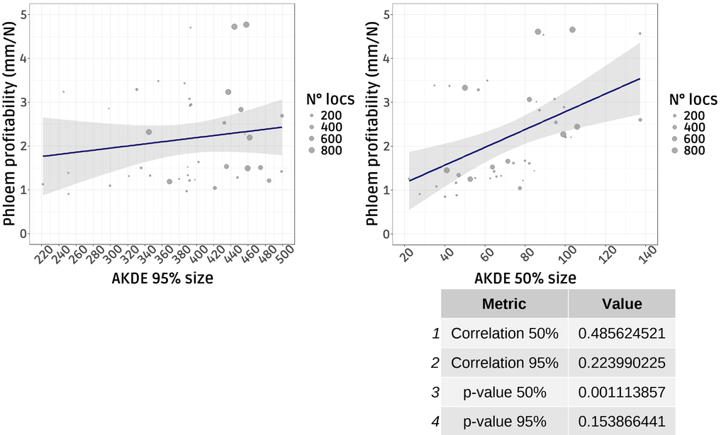

```r
cor_test_result_month_95 <- cor.test(hr_month$akde_95_area, hr_month$media_prof)
correlation_value_month_95 <- cor_test_result_month_95$estimate
p_value_month_95 <- cor_test_result_month_95$p.value

prof_akde95_plot <- ggplot(hr_month, aes(x = akde_95_area, y = media_prof)) +
  geom_jitter(aes(size = n_locs),
              alpha = 0.4 ,
              shape = 20,
              color = 'grey18',
              width = 0.3,
              height = 0.15) +
  geom_smooth(method = lm,
              size= 1.2,
              color = 'midnightblue',
              se = TRUE,
              alpha = 0.25) +
  scale_y_continuous(breaks = seq(0, 5, by = 1), limits = c(0, 5))+
  scale_x_continuous(breaks = seq(220, 600, by = 20), limits = c(220,500))+
  labs(y = "Phloem profitability (mm/N)",
       x = 'AKDE 95% size',
       size = 'N° locs') +
  theme_bw() +
  guides(color = 'none') +
  theme(text = element_text(
    family = "ruda",
    size = 46,
    face = 'bold'),
    axis.text.x = element_text(angle = 45, vjust = 0.8))

cor_test_result_month_50 <- cor.test(hr_month$akde_50_area, hr_month$media_prof)
correlation_value_month_50 <- cor_test_result_month_50$estimate
p_value_month_50 <- cor_test_result_month_50$p.value

prof_akde50_plot <- ggplot(hr_month, aes(x = akde_50_area, y = media_prof)) +
  geom_jitter(aes(size = n_locs),
              alpha = 0.4 ,
              shape = 20,
              color = 'grey18',
              width = 0.3,
              height = 0.15) +
  geom_smooth(method = lm,
              size= 1.2,
              color = 'midnightblue',
              se = TRUE,
              alpha = 0.25) +
  scale_y_continuous(breaks = seq(0, 5, by = 1), limits = c(0, 5))+
  scale_x_continuous(breaks = seq(0, 600, by = 20), limits = c(20, 140))+
  labs(y = "Phloem profitability (mm/N)",
       x = 'AKDE 50% size',
       size = 'N° locs') +
  theme_bw() +
  guides(color = 'none') +
  theme(text = element_text(
    family = "ruda",
    size = 46,
    face = 'bold'),
    axis.text.x = element_text(angle = 45, vjust = 0.8))


result_table <- data.frame(
  Metric = c("Correlation 50%", "Correlation 95%", "p-value 50%", "p-value 95%"),
  Value = c(correlation_value_month_50,
            correlation_value_month_95,
            p_value_month_50,
            p_value_month_95))


table_plot <- tableGrob(result_table, theme = ttheme_default(
  core = list(
    fg_params = list(fontsize = 45),
    padding = unit(c(10, 10), "mm")),
  colhead = list(
    fg_params = list(fontsize = 45),
    padding = unit(c(10, 10), "mm")),
  rowhead = list(
    fg_params = list(fontsize = 45),
    padding = unit(c(10, 10), "mm"))))


library(grid)


grid.arrange(
  prof_akde95_plot, prof_akde50_plot, NULL,
  table_plot,
  ncol = 2,
  heights = c(3, 1.5),
  padding = unit(4, "cm"))
```

## GLMM

#### AKDE 95% mensuales entre Arauco y PN Iguazú

Voy a tratar hacer unos GLM para ver qué variables explican las variaciones de los AKDE.

*Librerías*

```r
library(lme4)
library(glmmTMB)
```

Me estoy salteando cosas que ya hice, pero bueno. Acá pruebo varios modelos. Descarté las interacciones ya que no dieron significativas. Para no hacer chorrera ahora no los puse. Esto es para PNI y Arauco, así que va prop_bnsm y profitability no tienen sentido, pero despues hago para Arauco solo incluyendo ambas variables.

```r
modelo_gaussiano <- lmer(akde_95_area ~ area + productividad +(1 | grupo), data = hr_month)

modelo_gaussiano_nogroup <- lm(akde_95_area ~ area + productividad, data = hr_month)

modelo_gamma <- glmmTMB(akde_95_area ~ area  + productividad + (1 | grupo),
                        family = Gamma(link = "log"), data = hr_month)

hr_month$log_akde_95_area <- log(hr_month$akde_95_area)

modelo_lognormal <- lmer(log_akde_95_area ~ area + productividad + (1 | grupo), data = hr_month)
```

Paquetes para ver AIC y graficos de juste

```r
library('fitdistrplus')
library(cowplot)
```

Hago los gráficos y veo el AIC

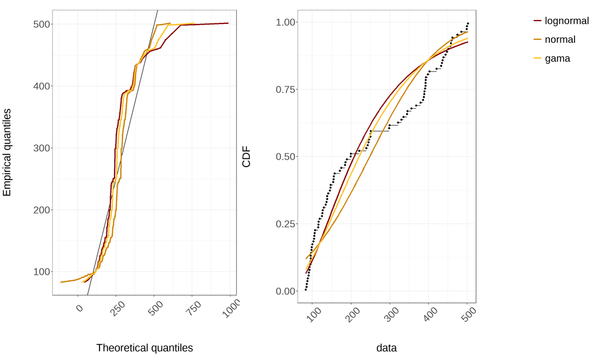

```r
normal=fitdist(hr_month$akde_95_area,"norm")

lognormal=fitdist(hr_month$akde_95_area,"lnorm")

gamma=fitdist(hr_month$akde_95_area,"gamma")


cdf.akde = cdfcomp(
  list(lognormal, normal, gamma),
  main = "",
  legendtext = c("lognormal", "normal", "gama"),
  fitcol = c("darkred", "orange3", "goldenrod1"),
  plotstyle = "ggplot") +
  geom_line(size = 1.2) +
  theme(
    axis.title = element_text(size = 38),
    axis.text = element_text(size = 36),
    axis.text.x = element_text(angle = 45,
                               vjust = 0.8),
    legend.position = c(1.6, 0.9),
    legend.text = element_text(size = 36))

qq.akde = qqcomp(
  list(lognormal, normal, gamma),
  main = "",
  fitcol = c("darkred", "orange3", "goldenrod1"),
  plotstyle     = "ggplot") +
  geom_line(size = 1.2) +
  theme_bw() +
  theme(
    axis.title = element_text(size = 38),
    axis.text = element_text(size = 36),
    axis.text.x = element_text(angle = 45,
                               vjust = 0.8),
    legend.position = "none")

plot_grid(qq.akde, cdf.akde, NULL, ncol = 3, rel_widths = c(1.5, 1.5, 0.75))
```

```r
gofstat(list(normal, lognormal, gamma),
        fitnames = c("normal","Lognormal","gamma"))[12]
```

```
## $aic
##    normal Lognormal     gamma
##  1213.263  1193.296  1194.366
```

Vamos con la lognormal.

```r
modelo_lognormal <- lmer(log_akde_95_area ~ area + productividad + (1 | grupo), data = hr_month)
```

#### Supuestos

Reviso los supuestos

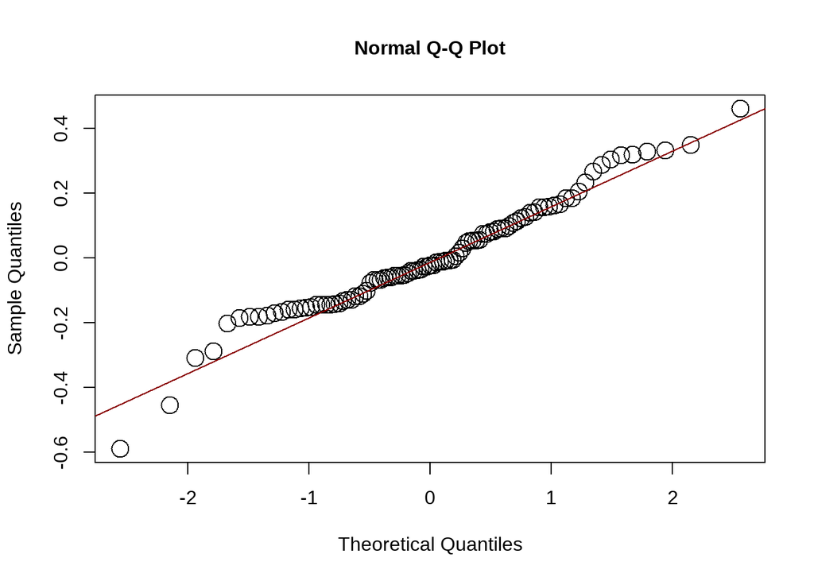

```r
qqnorm(residuals(modelo_lognormal), cex = 2,
       cex.axis = 2,
       cex.lab = 2,
       cex.main = 2)

qqline(residuals(modelo_lognormal), col='darkred', cex=9)
```

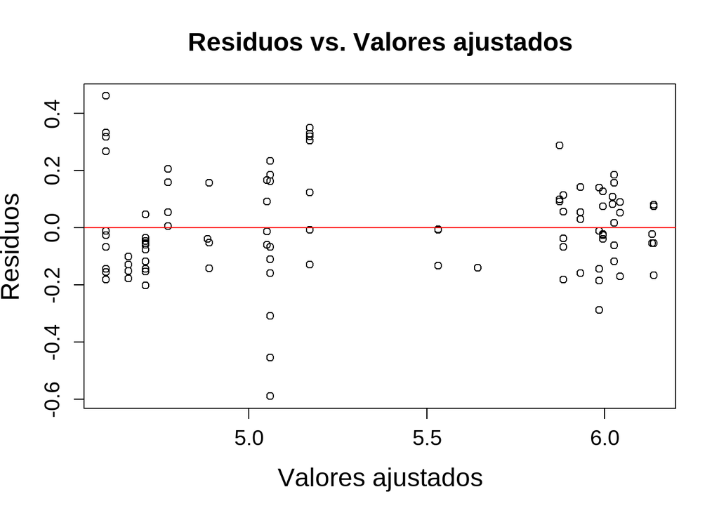

```r
plot(fitted(modelo_lognormal), residuals(modelo_lognormal),
     xlab = "Valores ajustados", ylab = "Residuos",
     main = "Residuos vs. Valores ajustados",
     cex.lab = 3,
     cex.main = 3,
     cex.axis = 2.5)

abline(h = 0, col = "red")
```

Hago un test para ver la homogeneidad porque el gráfico no me da mucha seguridad

```r
library(lmtest)

residuos <- residuals(modelo_lognormal)

valores_ajustados <- fitted(modelo_lognormal)

# Ajustar un modelo auxiliar con los residuos

modelo_aux <- lm(residuos^2 ~ valores_ajustados)

# Prueba de Breusch-Pagan en el modelo auxiliar

bptest(modelo_aux)
```

```
##
##  studentized Breusch-Pagan test
##
## data:  modelo_aux
## BP = 1.6116, df = 1, p-value = 0.2043
```

Los residuos parecen seguir una distribución normal y no muestran evidencia de heterocedasticidad en las varianzas

#### Modelo

```r
summary(modelo_lognormal)
```

```
## Linear mixed model fit by REML ['lmerMod']
## Formula: log_akde_95_area ~ area + productividad + (1 | grupo)
##    Data: hr_month
##
## REML criterion at convergence: -18.3
##
## Scaled residuals:
##     Min      1Q  Median      3Q     Max
## -3.1972 -0.6958 -0.1176  0.5641  2.5084
##
## Random effects:
##  Groups   Name        Variance Std.Dev.
##  grupo    (Intercept) 0.04158  0.2039
##  Residual             0.03386  0.1840
## Number of obs: 95, groups:  grupo, 12
##
## Fixed effects:
##                   Estimate Std. Error t value
## (Intercept)        5.87767    0.09036  65.045
## areapni           -1.05792    0.12719  -8.318
## productividadBaja  0.11178    0.03948   2.832
##
## Correlation of Fixed Effects:
##             (Intr) areapn
## areapni     -0.677
## prodctvddBj -0.201 -0.026
```

```r
library(MuMIn)
r_squared <- r.squaredGLMM(modelo_lognormal)
r_squared
```

```
##            R2m       R2c
## [1,] 0.7885223 0.9050729
```

El modelo utilizado básicamente ve cómo varía el AKDE 95% de los caí en funcion del ‘area’ (PNI Iguazú vs Arauco) y de la productividad (baja o alta). Además se incluyó al grupo como factor aleatorio.

*Relación entre la Variable Respuesta y las Variables Explicativas*: Intercepto (para arauco con productividad alta): El valor del intercepto, 5.88, representa el logaritmo del aKDE 95% para arauco y durante los meses de productividad alta. Si volvemos a la escala original, este valor corresponde a un AKDE de:

$$\text{Área de acción} = e^{5.88} \approx 357$$

**Efecto del área** (pni comparado con arauco): El coeficiente para pni es -1.06, lo que indica que los animales en PNI tienden a tener un AKDE más pequeño que en arauco. Específicamente, esta reducción es aproximadamente del 65% en términos de la escala original:

$$\text{Reducción del AKDE} = e^{-1.06} \approx 0.35$$

Esto sugiere que los cai en PNI tienden a utilizar AKDE considerablemente más pequeñas.

**Efecto de la productividad** (productividad baja comparada con alta): El coeficiente para la productividad baja es 0.11, lo que indica que en áreas de productividad baja, los caí tienden a tener AKDE ligeramente más grandes en comparación con áreas de alta productividad. Esto corresponde a un incremento del 11.8% en el AKDE:

$$\text{Aumento del AKDE} = e^{0.11} \approx 1.12$$

Este resultado puede indicar que en áreas con menor productividad, los animales necesitan cubrir una mayor área para satisfacer sus necesidades de recursos, lo cual es coherente con patrones de comportamiento en muchas especies.

**Efectos Aleatorios** (Variación entre Grupos): El efecto aleatorio por grupo tiene una varianza de 0.04158, lo que implica que existe variación en el AKDE 95% entre los diferentes grupos de caí, aunque esta variación es relativamente pequeña. La desviación estándar del efecto aleatorio es 0.2039, lo que sugiere que las diferencias entre grupos no son drásticas, pero aún así, los grupos exhiben ciertas diferencias en el uso del espacio.

En general, la varianza residual es 0.03386, lo que refleja la cantidad de variabilidad no explicada por las variables del modelo. Dado que la R² marginal (78.9%) y la R² condicional (90.5%) son altas, esto indica que tanto las variables fijas (área y productividad) como el efecto aleatorio (grupo) explican una parte importante de la variabilidad en el área de utilización.

```r
hr_month$predicted_log <- predict(modelo_lognormal)
hr_month$predicted_area <- exp(hr_month$predicted_log)
```

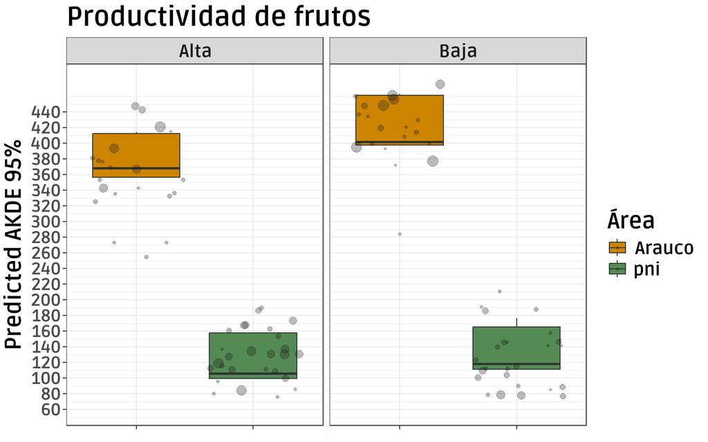

```r
ggplot(hr_month, aes(x = area, y = predicted_area, fill = area)) +
    facet_wrap( ~ productividad) +
    geom_boxplot(outlier.shape = NA) +
    scale_fill_manual(values = colores) +
    geom_jitter(
      aes(size = n_locs),
      alpha = 0.3,
      shape = 20,
      color = 'grey10',
      width = 0.4,
      height = 35) +
    scale_y_continuous(breaks = seq(60,
                                    450,
                                    by = 20),
                       limits = c(60,
                                  480)) +
    theme_bw() +
    guides(size = "none",
           alpha = "none",
           color = "none") +
    labs(y = "Predicted AKDE 95%",
         title = "Productividad de frutos",
         fill = "Área") +
    guides(alpha = "none",
           color = "none") +
    theme(
      text = element_text(
        family = "ruda",
        size = 37,
        face = 'bold'),
      axis.text.x = element_text(
        size = 0,
        angle = 45,
        color = "grey18",
        vjust = 0.6,
        hjust = 0.5),
      axis.title.x = element_text(size = 0),
      axis.text = element_text(size = 32),
      axis.text.y = element_text(size = 28),
      axis.title.y = element_text(size = 37,
                                  face = "bold",
                                  vjust = 1.5))
```